# 2.4 Exercises

## 2.4 Exercises

### Conceptual

**1.** For each of parts (a) through (d), indicate whether we would generally expect the performance of a ﬂexible statistical learning method to be better or worse than an inﬂexible method. Justify your answer.

- (a) The sample size n is extremely large, and the number of predictors p is small.

  *better - a more flexible approach will fit the data closer and with the large sample size a better fit than an inflexible approach would be obtained*
- (b) The number of predictors p is extremely large, and the numberof observations n is small.

  *worse - a flexible method would overfit the small number of observations*
- (c) The relationship between the predictors and response is highly non-linear.

  *better - with more degrees of freedom, a flexible model would obtain a better fit*
- (d) The variance of the error terms, i.e. $\sigma^2 = Var(\varepsilon)$, is extremely high.

  *worse - flexible methods fit to the noise in the error terms and increase variance*

**2.** Explain whether each scenario is a classification or regression problem, and indicate whether we are most interested in inference or prediction. Finally, provide $n$ and $p$.

- (a) We collect a set of data on the top 500 firms in the US. For each firm we record profit, number of employees, industry and the CEO salary. We are interested in understanding which factors affect CEO salary.

  regression; inference; quantitative output of CEO salary based on CEO firm's features  
  $n = 500$ - firms in the US  
  $p = 3$ - profit, number of employees, industry
- (b) We are considering launching a new product and wish to know whether it will be a success or a failure. We collect data on 20 similar products that were previously launched. For each product we have recorded whether it was a success or failure, price charged for the product, marketing budget, competition price, and ten other variables.

  classification; prediction; predicting new product's success or failure  
  $n = 20$ - similar products previously launched  
  $p = 13$ - price charged, marketing budget, comp. price, ten other variables
- (c) We are interesting in predicting the % change in the US dollar in relation to the weekly changes in the world stock markets. Hence we collect weekly data for all of 2012. For each week we record the % change in the dollar, the % change in the US market, the % change in the British market, and the % change in the German market.

  regression; prediction; quantitative output of % change  
  $n = 52$ - weeks of 2012 weekly data  
  $p = 3$ - % change in US market, % change in British market, % change in German market

*3.* We now revisit the bias-variance decomposition.

- (a) Provide a sketch of typical (squared) bias, variance, training error, test error, and Bayes (or irreducible) error curves, on a single plot, as we go from less flexible statistical learning methods towards more flexible approaches. The x-axis should represent the amount of flexibility in the method, and the y-axis should represent the values for each curve. There should be five curves. Make sure to label each one.

[figure not shown]

- (b) Explain why each of the ﬁve curves has the shape displayed in part (a).

  *The training MSE declines monotonically as flexibility increases, this is because as flexibility increases the $f$ curve fits the observed data more closely. The test MSE intially declines as flexibility increases but at some point it levels off and then starts to increase again (U-shape), this is because when a $f$ curve yields a small training MSE but a large test MSE we are actually overfitting the data (our procedure tries too hard to find patterns in the training data that are maybe only caused by chance rather than by true properties of the unknown $f$). The squared bias decreases monotonically and the variance increases monotonically; as a general rule, as we use more flexible methods, the variance will increase and the bias will decrease. Variance refers to the amount by wich $\hat{f}$ would change if we estimated it using a different training data set, so if the curve fits the observations very closely, changing any point may cause $\hat{f}$ to change considerably, and so will result in some variance. Bias refers to the error that is introduced by approximating a real-life problem by a much simpler model, so if we use a very simple model (linear regression) it is unlikely that any real-life problem has such a simple linear relationship, and so performing linear regression will result in some bias in the estimate of $f$. The irreducible error is a constant so it is a parallel line, this curve lies below the test MSE curve because the expected test MSE will always be greater the $Var(\varepsilon)$ (see relation $(2.7)$).*

**4.** You will now think of some real-life applications for statistical learning.

- (a) Describe three real-life applications in which classification might be useful. Describe the response, as well as the predictors. Is the goal of each application inference or prediction ? Explain your answer.

  Classification 1 – Is this TV series/movie/ad campaign going to be successful or not (Response : Success/Failure, Predictors : Money spent, Talent, Running Time, Producer, TV Channel, Air time slot, etc., Goal : Prediction).  
  Classification 2 – Should this applicant be admitted into Harvard University or not (Response : Admit/Not admit, Predictors : SAT Scores, GPA, Socio Economic Strata, Income of parents, Essay effectiveness, Potential, etc., Goal : Prediction).  
  Classification 3 – Salk Polio vaccine trials – Successful/Not Successful (Response : Did the child get polio or not, Predictors : Age, Geography, General health condition, Control/Test group, etc., Goal : Prediction).
- (b) Describe three real-life applications in which regression might be useful. Describe the response, as well as the predictors. Is the goal of each application inference or prediction ? Explain your answer.

  Regression 1 – GDP Growth in European economies (Response : What is the GDP of countries predicted to be by 2050, Predictors : Population, Per capita income, Education, Average life expectancy, Tax Revenue, Government Spending etc., Goal : Inference).  
  Regression 2 – What is the average house sale price in XXX neighborhood over the next 5 years (Response : Average house in XXX neighborhood will sell for Y next year, Z the year after, T after that, etc., Predictors : Proximity to transit, Parks, Schools, Average size of family, Average Income of Family, Crime Rate, Price Flux in surrounding neighborhoods etc., Goal : Inference).  
  Regression 3 – Gas mileage that a new car design will result in (Response : With certain parameters being set, X is the mileage we will get out of this car, Predictors: Fuel type, Number of Cylinders, Engine Version, etc., Goal : Inference).
- (c) Describe three real-life applications in which cluster analysis might be useful.

  Cluster 1 – Division of countries into Developed, Developing and Third World (Response : By 2050, countries in Asia can be split into these following clusters, Predictors : Per Capita Income, Purchasing power parity, Average birth rate, Average number of years of education received, Average Death Rate, Population etc., Goal: Prediction).  
  Cluster 2 – Division of average working population into income segments for taxation purposes (Response : This worker falls under this taxation bracket, Predictors : Income, Job Industry, Job Segment, Size of Company, etc., Goal : Prediction).  
  Cluster 3 – Cluster new movies being produced into ratings G/PG/R/PG-13 etc. (Response : This movie is a R/PG/PG-13, Predictors : Violent content, Sexual language, theme, etc., Goal : Prediction).

**5.** What are the advantages and disadvantages of a very ﬂexible (versus a less ﬂexible) approach for regression or classiﬁcation ? Under what circumstances might a more ﬂexible approach be preferred to a less ﬂexible approach? When might a less ﬂexible approach be preferred ?

*The advantages for a very flexible approach for regression or classification are obtaining a better fit for non-linear models, decreasing bias.*

*The disadvantages for a very flexible approach for regression or classification are requires estimating a greater number of parameters, follow the noise too closely (overfit), increasing variance.*

*A more flexible approach would be preferred to a less flexible approach when we are interested in prediction and not the interpretability of the results.*

*A less flexible approach would be preferred to a more flexible approach when we are interested in inference and the interpretability of the results.*

[output not shown]

**6.** Describe the differences between a parametric and a non-parametric statistical learning approach. What are the advantages of a parametric approach to regression or classification (as opposed to a nonparametric approach) ? What are its disadvantages ?

*A parametric approach reduces the problem of estimating f down to one of estimating a set of parameters because it assumes a form for f.*

*A non-parametric approach does not assume a functional form for f and so requires a very large number of observations to accurately estimate f.*

*The advantages of a parametric approach to regression or classification are the simplifying of modeling f to a few parameters and not as many observations are required compared to a non-parametric approach.*

*The disadvantages of a parametric approach to regression or classification are a potential to inaccurately estimate f if the form of f assumed is wrong or to overfit the observations if more flexible models are used.*

| Parametric | Non-parametric |
| --- | --- |
| Reduces the problem of estimating $f$ to estimating a set of parameters. | Seek an estimate of $f$ that gets as close to the data points as possible without being too rough or wiggly. |
| Simplifies the problem because it is generally easier to estimate a set of parameters than to ﬁt an entirely arbitrary function. | May accurately ﬁt a wider range of possible shapes for $f$. |
| If we use more ﬂexible models it may lead to overﬁtting the data. | A very large number of observations is required to obtain an accurate estimate for $f$. |

**7.** The table below provides a training data set containing 6 observations, 3 predictors, and 1 qualitative response variable. Suppose we wish to use this data set to make a prediction for Y when X1 = X2 = X3 = 0 using K-nearest neighbors.

- (a) Compute the Euclidean distance between each observation and the test point, X1 = X2 = X3 = 0.

| Obs. | X1 | X2 | X3 | Distance(0, 0, 0) | Y |
| --- | --- | --- | --- | --- | --- |
| 1 | 0 | 3 | 0 | 3 | Red |
| 2 | 2 | 0 | 0 | 2 | Red |
| 3 | 0 | 1 | 3 | sqrt(10) ~ 3.16 | Red |
| 4 | 0 | 1 | 2 | sqrt(5) ~ 2.23 | Green |
| 5 | -1 | 0 | 1 | sqrt(2) ~ 1.41 | Green |
| 6 | 1 | 1 | 1 | sqrt(3) ~ 1.73 | Red |

- (b) What is our prediction with $K = 1$ ? Why ?

  If $K = 1$ then $x_5\in\mathcal{N}_0$ and we have

  $P(Y = \mathrm{Red} | X = x_0) = \frac{1}{1}\sum_{i\in\mathcal{N}_0}I(y_i = \mathrm{Red}) = I(y_5 = \mathrm{Red}) = 0$

  and

  $P(Y = \mathrm{Green} | X = x_0) = \frac{1}{1}\sum_{i\in\mathcal{N}_0}I(y_i = \mathrm{Green}) = I(y_5 = \mathrm{Green}) = 1.$

  *Our prediction is then Green. Observation 5 is the closest neighbor for K = 1.*
- (c) What is our prediction with $K = 3$ ? Why ?

  If $K = 3$ then $x_2,x_5,x_6\in\mathcal{N}_0$ and we have

  $P(Y = \mathrm{Red} | X = x_0) = \frac{1}{3}\sum_{i\in\mathcal{N}_0}I(y_i = \mathrm{Red}) = \frac{1}{3}(1 + 0 + 1) = \frac{2}{3}$

  and

  $P(Y = \mathrm{Green} | X = x_0) = \frac{1}{3}\sum_{i\in\mathcal{N}_0}I(y_i = \mathrm{Green}) = \frac{1}{3}(0 + 1 + 0) = \frac{1}{3}.$

  *Our prediction is then Red. Observations 2, 5, 6 are the closest neighbors for K = 3. 2 is Red, 5 is Green, and 6 is Red.*
- (d) If the Bayes decision boundary in this problem is highly nonlinear, then would we expect the best value for $K$ to be large or small ? Why ?

  *Small. A small $K$ would be flexible for a non-linear decision boundary, whereas a large $K$ would try to fit a more linear boundary because it takes more points into consideration. As $K$ becomes larger, the boundary becomes smoother.*

### Applied

**8.** This exercise relates to the *College* data set, which can be found in the file *College.csv*. It contains a number of variables for 777 different universities and colleges in the US. The variables are:

- *Private* : Public/private indicator
- *Apps* : Number of applications received
- *Accept* : Number of applicants accepted
- *Enroll* : Number of new students enrolled
- *Top10perc* : New students from top 10 % of high school class
- *Top25perc* : New students from top 25 % of high school class
- *F.Undergrad* : Number of full-time undergraduates
- *P.Undergrad* : Number of part-time undergraduates
- *Outstate* : Out-of-state tuition
- *Room.Board* : Room and board costs
- *Books* : Estimated book costs
- *Personal* : Estimated personal spending
- *PhD* : Percent of faculty with Ph.D.’s
- *Terminal* : Percent of faculty with terminal degree
- *S.F.Ratio* : Student/faculty ratio
- *perc.alumni* : Percent of alumni who donate
- *Expend* : Instructional expenditure per student
- *Grad.Rate* : Graduation rate

Before reading the data into R, it can be viewed in Excel or a text editor.

- (a) Use the *read.csv()* function to read the data into *R*. Call the loaded data *college*. Make sure that you have the directory set to the correct location for the data.

```r
college = read.csv("../../../data/College.csv")
```

- (b) Look at the data using the *fix()* function. You should notice that the first column is just the name of each university. We don't really want *R* to treat this as data. However, it may be handy to have these names for later.

```r
head(college)
```

| X | Private | Apps | Accept | Enroll | Top10perc | Top25perc | F.Undergrad | P.Undergrad | Outstate | Room.Board | Books | Personal | PhD | Terminal | S.F.Ratio | perc.alumni | Expend | Grad.Rate |
| --- | --- | --- | --- | --- | --- | --- | --- | --- | --- | --- | --- | --- | --- | --- | --- | --- | --- | --- |
| Abilene Christian University | Yes | 1660 | 1232 | 721 | 23 | 52 | 2885 | 537 | 7440 | 3300 | 450 | 2200 | 70 | 78 | 18.1 | 12 | 7041 | 60 |
| Adelphi University | Yes | 2186 | 1924 | 512 | 16 | 29 | 2683 | 1227 | 12280 | 6450 | 750 | 1500 | 29 | 30 | 12.2 | 16 | 10527 | 56 |
| Adrian College | Yes | 1428 | 1097 | 336 | 22 | 50 | 1036 | 99 | 11250 | 3750 | 400 | 1165 | 53 | 66 | 12.9 | 30 | 8735 | 54 |
| Agnes Scott College | Yes | 417 | 349 | 137 | 60 | 89 | 510 | 63 | 12960 | 5450 | 450 | 875 | 92 | 97 | 7.7 | 37 | 19016 | 59 |
| Alaska Pacific University | Yes | 193 | 146 | 55 | 16 | 44 | 249 | 869 | 7560 | 4120 | 800 | 1500 | 76 | 72 | 11.9 | 2 | 10922 | 15 |
| Albertson College | Yes | 587 | 479 | 158 | 38 | 62 | 678 | 41 | 13500 | 3335 | 500 | 675 | 67 | 73 | 9.4 | 11 | 9727 | 55 |

```r
rownames(college) = college[,1]
head(college[, 1:5])
```

|  | X | Private | Apps | Accept | Enroll |
| --- | --- | --- | --- | --- | --- |
| Abilene Christian University | Abilene Christian University | Yes | 1660 | 1232 | 721 |
| Adelphi University | Adelphi University | Yes | 2186 | 1924 | 512 |
| Adrian College | Adrian College | Yes | 1428 | 1097 | 336 |
| Agnes Scott College | Agnes Scott College | Yes | 417 | 349 | 137 |
| Alaska Pacific University | Alaska Pacific University | Yes | 193 | 146 | 55 |
| Albertson College | Albertson College | Yes | 587 | 479 | 158 |

You should see that there is now a *row.names* column with the name of each university recorded. This means that *R* has given each row a name corresponding to the appropriate university. *R* will not try to perform calculations on the row names. However, we still need to eliminate the ﬁrst column in the data where the names are stored.

```r
college = college[,-1]
head(college[, 1:5])
```

|  | Private | Apps | Accept | Enroll | Top10perc |
| --- | --- | --- | --- | --- | --- |
| Abilene Christian University | Yes | 1660 | 1232 | 721 | 23 |
| Adelphi University | Yes | 2186 | 1924 | 512 | 16 |
| Adrian College | Yes | 1428 | 1097 | 336 | 22 |
| Agnes Scott College | Yes | 417 | 349 | 137 | 60 |
| Alaska Pacific University | Yes | 193 | 146 | 55 | 16 |
| Albertson College | Yes | 587 | 479 | 158 | 38 |

Now you should see that the ﬁrst data column is *Private*. Note that another column labeled row.names now appears before the *Private* column. However, this is not a data column but rather the name that *R* is giving to each row.

- (c) *i.* Use the *summary()* function to produce a numerical summary of the variables in the data set.

```r
summary(college)
```

```
 Private        Apps           Accept          Enroll       Top10perc
 No :212   Min.   :   81   Min.   :   72   Min.   :  35   Min.   : 1.00
 Yes:565   1st Qu.:  776   1st Qu.:  604   1st Qu.: 242   1st Qu.:15.00
           Median : 1558   Median : 1110   Median : 434   Median :23.00
           Mean   : 3002   Mean   : 2019   Mean   : 780   Mean   :27.56
           3rd Qu.: 3624   3rd Qu.: 2424   3rd Qu.: 902   3rd Qu.:35.00
           Max.   :48094   Max.   :26330   Max.   :6392   Max.   :96.00
   Top25perc      F.Undergrad     P.Undergrad         Outstate
 Min.   :  9.0   Min.   :  139   Min.   :    1.0   Min.   : 2340
 1st Qu.: 41.0   1st Qu.:  992   1st Qu.:   95.0   1st Qu.: 7320
 Median : 54.0   Median : 1707   Median :  353.0   Median : 9990
 Mean   : 55.8   Mean   : 3700   Mean   :  855.3   Mean   :10441
 3rd Qu.: 69.0   3rd Qu.: 4005   3rd Qu.:  967.0   3rd Qu.:12925
 Max.   :100.0   Max.   :31643   Max.   :21836.0   Max.   :21700
   Room.Board       Books           Personal         PhD
 Min.   :1780   Min.   :  96.0   Min.   : 250   Min.   :  8.00
 1st Qu.:3597   1st Qu.: 470.0   1st Qu.: 850   1st Qu.: 62.00
 Median :4200   Median : 500.0   Median :1200   Median : 75.00
 Mean   :4358   Mean   : 549.4   Mean   :1341   Mean   : 72.66
 3rd Qu.:5050   3rd Qu.: 600.0   3rd Qu.:1700   3rd Qu.: 85.00
 Max.   :8124   Max.   :2340.0   Max.   :6800   Max.   :103.00
    Terminal       S.F.Ratio      perc.alumni        Expend
 Min.   : 24.0   Min.   : 2.50   Min.   : 0.00   Min.   : 3186
 1st Qu.: 71.0   1st Qu.:11.50   1st Qu.:13.00   1st Qu.: 6751
 Median : 82.0   Median :13.60   Median :21.00   Median : 8377
 Mean   : 79.7   Mean   :14.09   Mean   :22.74   Mean   : 9660
 3rd Qu.: 92.0   3rd Qu.:16.50   3rd Qu.:31.00   3rd Qu.:10830
 Max.   :100.0   Max.   :39.80   Max.   :64.00   Max.   :56233
   Grad.Rate
 Min.   : 10.00
 1st Qu.: 53.00
 Median : 65.00
 Mean   : 65.46
 3rd Qu.: 78.00
 Max.   :118.00
```

*ii.* Use the *pairs()* function to produce a scatterplot matrix of the ﬁrst ten columns or variables of the data. Recall that you can reference the ﬁrst ten columns of a matrix *A* using *A[,1:10]*.

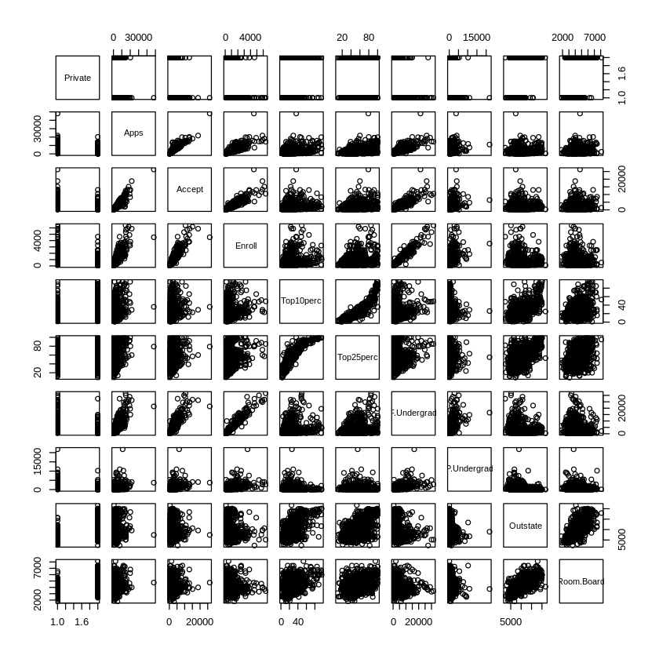

```r
pairs(college[,1:10])
```

*iii.* Use the *plot()* function to produce side-by-side boxplots of *Outstate* versus *Private*.

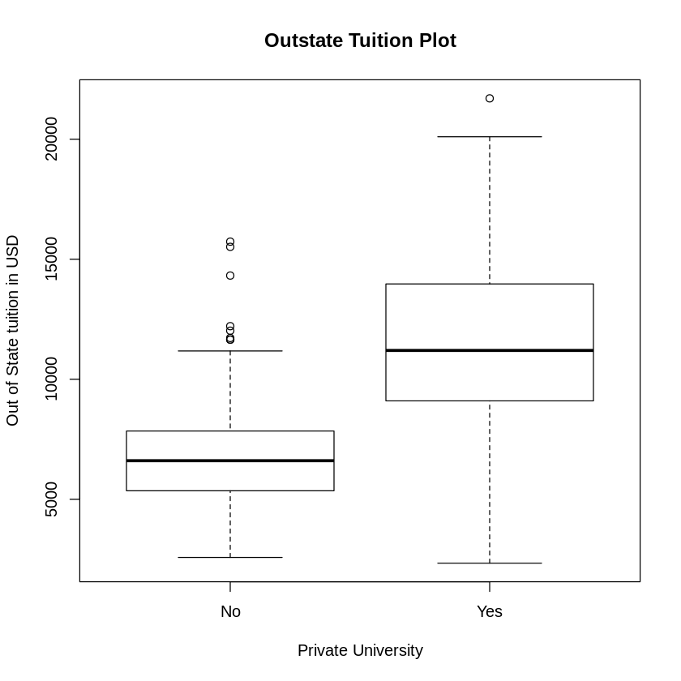

```r
plot(college$Private, college$Outstate,
     xlab = "Private University", ylab = "Out of State tuition in USD", main = "Outstate Tuition Plot")
```

*iv.* Create a new qualitative variable, called *Elite*, by binning the *Top10perc* variable. We are going to divide universities into two groups based on whether or not the proportion of students coming from the top 10% of their high school classes exceeds 50%.

```r
Elite = rep("No", nrow(college))
Elite[college$Top10perc > 50] = "Yes"
Elite = as.factor(Elite)
college = data.frame(college, Elite)
```

Use the *summary()* function to see how many elite universities there are. Now use the *plot()* function to produce side-by-side boxplots of *Outstate* versus *Elite*.

```r
summary(college$Elite)
```

**No**

699

**Yes**

78

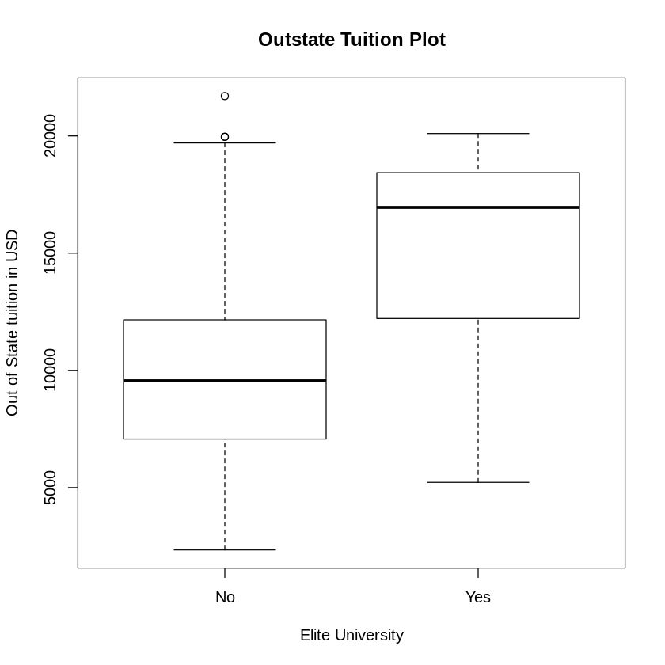

```r
plot(college$Elite, college$Outstate,
     xlab = "Elite University", ylab ="Out of State tuition in USD", main = "Outstate Tuition Plot")
```

*v.* Use the *hist()( function to produce some histograms with diﬀering numbers of bins for a few of the quantitative variables. You may ﬁnd the command* par(mfrow=c(2,2))* useful: it will divide the print window into four regions so that four plots can be made simultaneously. Modifying the arguments to this function will divide the screen in other ways

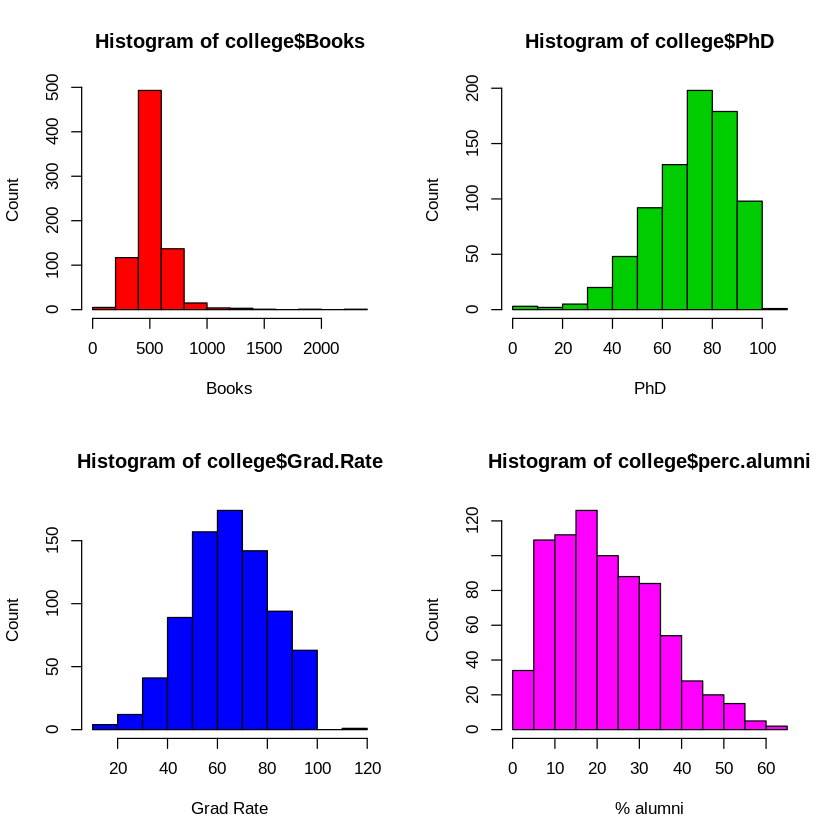

```r
par(mfrow = c(2,2))
hist(college$Books, col = 2, xlab = "Books", ylab = "Count")
hist(college$PhD, col = 3, xlab = "PhD", ylab = "Count")
hist(college$Grad.Rate, col = 4, xlab = "Grad Rate", ylab = "Count")
hist(college$perc.alumni, col = 6, xlab = "% alumni", ylab = "Count")
```

*vi.* Continue exploring the data, and provide a brief summary of what you discover.

```r
summary(college$PhD)
```

```
   Min. 1st Qu.  Median    Mean 3rd Qu.    Max.
   8.00   62.00   75.00   72.66   85.00  103.00
```

*It is a little weird to have universities with $103\%$ of faculty with Phd's, let us see how many universities have this percentage and their names.*

```r
weird.phd = college[college$PhD == 103, ]
nrow(weird.phd)
```

1

```r
rownames(weird.phd)
```

'Texas A&M University at Galveston'

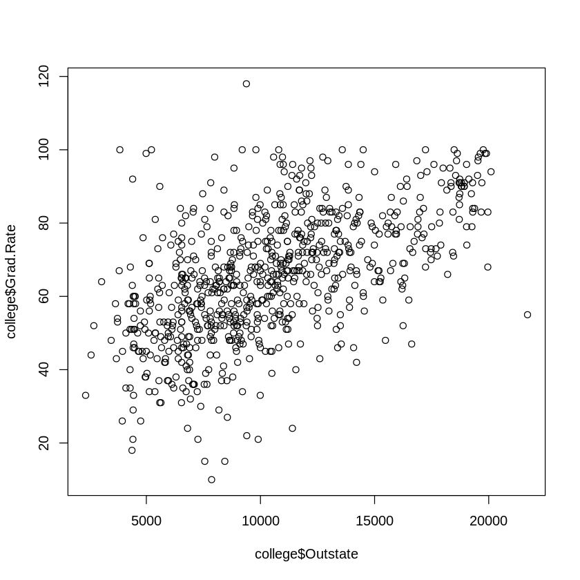

```r
par(mfrow=c(1,1))
plot(college$Outstate, college$Grad.Rate)
```

*High tuition correlates to high graduation rate.*

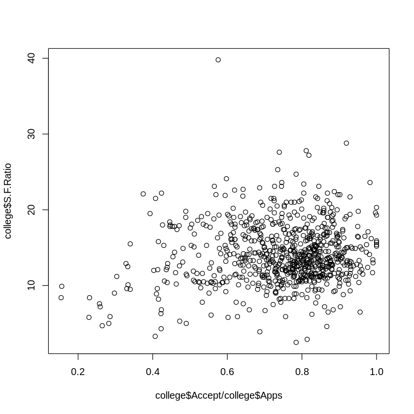

```r
plot(college$Accept / college$Apps, college$S.F.Ratio)
```

*Colleges with low acceptance rate tend to have low S:F ratio.*

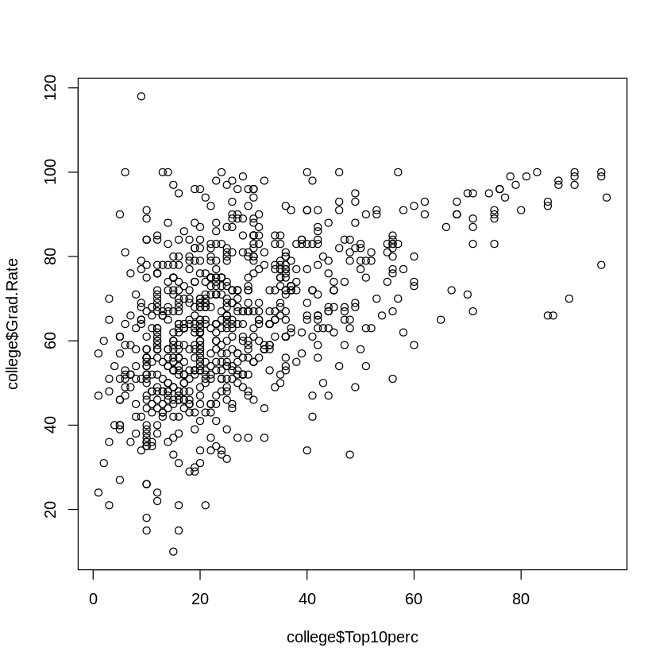

```r
plot(college$Top10perc, college$Grad.Rate)
```

*Colleges with the most students from top 10% perc don't necessarily have the highest graduation rate. Also, rate > 100 is erroneous!*

**9.** This exercise involves the Auto data set studied in the lab. Make sure that the missing values have been removed from the data.

- (a) Which of the predictors are quantitative, and which are qualitative ?

```r
Auto = read.csv("../../../data/Auto.csv", header=T, na.strings="?")
Auto = na.omit(Auto)
```

```r
str(Auto)
```

```
'data.frame':	392 obs. of  9 variables:
 $ mpg         : num  18 15 18 16 17 15 14 14 14 15 ...
 $ cylinders   : int  8 8 8 8 8 8 8 8 8 8 ...
 $ displacement: num  307 350 318 304 302 429 454 440 455 390 ...
 $ horsepower  : int  130 165 150 150 140 198 220 215 225 190 ...
 $ weight      : int  3504 3693 3436 3433 3449 4341 4354 4312 4425 3850 ...
 $ acceleration: num  12 11.5 11 12 10.5 10 9 8.5 10 8.5 ...
 $ year        : int  70 70 70 70 70 70 70 70 70 70 ...
 $ origin      : int  1 1 1 1 1 1 1 1 1 1 ...
 $ name        : Factor w/ 304 levels "amc ambassador brougham",..: 49 36 231 14 161 141 54 223 241 2 ...
 - attr(*, "na.action")=Class 'omit'  Named int [1:5] 33 127 331 337 355
  .. ..- attr(*, "names")= chr [1:5] "33" "127" "331" "337" ...
```

```r
summary(Auto)
```

```
      mpg          cylinders      displacement     horsepower        weight
 Min.   : 9.00   Min.   :3.000   Min.   : 68.0   Min.   : 46.0   Min.   :1613
 1st Qu.:17.00   1st Qu.:4.000   1st Qu.:105.0   1st Qu.: 75.0   1st Qu.:2225
 Median :22.75   Median :4.000   Median :151.0   Median : 93.5   Median :2804
 Mean   :23.45   Mean   :5.472   Mean   :194.4   Mean   :104.5   Mean   :2978
 3rd Qu.:29.00   3rd Qu.:8.000   3rd Qu.:275.8   3rd Qu.:126.0   3rd Qu.:3615
 Max.   :46.60   Max.   :8.000   Max.   :455.0   Max.   :230.0   Max.   :5140

  acceleration        year           origin                      name
 Min.   : 8.00   Min.   :70.00   Min.   :1.000   amc matador       :  5
 1st Qu.:13.78   1st Qu.:73.00   1st Qu.:1.000   ford pinto        :  5
 Median :15.50   Median :76.00   Median :1.000   toyota corolla    :  5
 Mean   :15.54   Mean   :75.98   Mean   :1.577   amc gremlin       :  4
 3rd Qu.:17.02   3rd Qu.:79.00   3rd Qu.:2.000   amc hornet        :  4
 Max.   :24.80   Max.   :82.00   Max.   :3.000   chevrolet chevette:  4
                                                 (Other)           :365
```

Quantitative variables: mpg, cylinders, displacement, horsepower, weight, acceleration, year  
Qualitative variables: name, origin

- (b) What is the range of each quantitative predictor? You can answer this using the *range()* function.

```r
sapply(Auto[, 1:7], range)
```

| mpg | cylinders | displacement | horsepower | weight | acceleration | year |
| --- | --- | --- | --- | --- | --- | --- |
| 9.0 | 3 | 68 | 46 | 1613 | 8.0 | 70 |
| 46.6 | 8 | 455 | 230 | 5140 | 24.8 | 82 |

- (c) What is the mean and standard deviation of each quantitative predictor?

```r
sapply(Auto[, 1:7], mean)
```

**mpg**

23.4459183673469

**cylinders**

5.4719387755102

**displacement**

194.411989795918

**horsepower**

104.469387755102

**weight**

2977.58418367347

**acceleration**

15.5413265306122

**year**

75.9795918367347

```r
sapply(Auto[, 1:7], sd)
```

**mpg**

7.8050074865718

**cylinders**

1.70578324745278

**displacement**

104.644003908905

**horsepower**

38.4911599328285

**weight**

849.402560042949

**acceleration**

2.75886411918808

**year**

3.68373654357783

- (d) Now remove the 10th through 85th observations. What is the range, mean, and standard deviation of each predictor in the subset of the data that remains?

```r
subsetAuto = Auto[-(10:85),]
sapply(subsetAuto[, 1:7], range)
```

| mpg | cylinders | displacement | horsepower | weight | acceleration | year |
| --- | --- | --- | --- | --- | --- | --- |
| 11.0 | 3 | 68 | 46 | 1649 | 8.5 | 70 |
| 46.6 | 8 | 455 | 230 | 4997 | 24.8 | 82 |

```r
sapply(subsetAuto[, 1:7], mean)
```

**mpg**

24.4044303797468

**cylinders**

5.37341772151899

**displacement**

187.240506329114

**horsepower**

100.721518987342

**weight**

2935.97151898734

**acceleration**

15.7268987341772

**year**

77.1455696202532

```r
sapply(subsetAuto[, 1:7], sd)
```

**mpg**

7.86728282443069

**cylinders**

1.65417865185607

**displacement**

99.6783672303628

**horsepower**

35.7088532738003

**weight**

811.30020815829

**acceleration**

2.69372071752036

**year**

3.10621690872137

- (e) Using the full data set, investigate the predictors graphically, using scatterplots or other tools of your choice. Create some plots highlighting the relationships among the predictors. Comment on your ﬁndings.

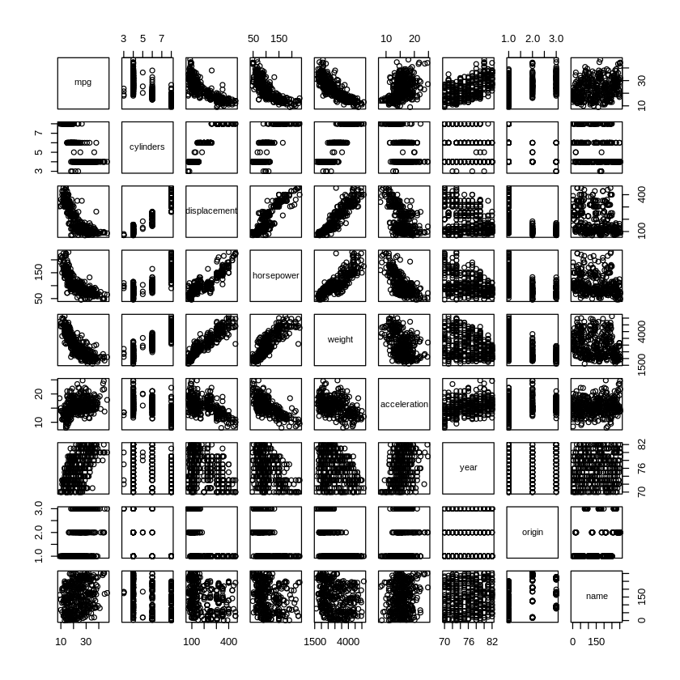

```r
pairs(Auto)
```

*We seem to get more mileage per gallon on a 4 cyl vehicle than the others. Weight, displacement and horsepower seem to have an inverse eﬀect with mpg. We see an overall increase in mpg over the years. Almost doubled in one decade. Japanese cars have higher mpg than US or European cars.*

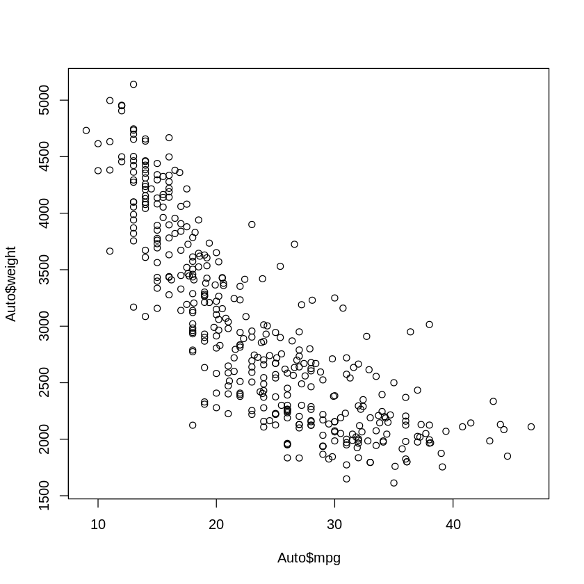

```r
plot(Auto$mpg, Auto$weight)
```

*Heavier weight correlates with lower mpg.*

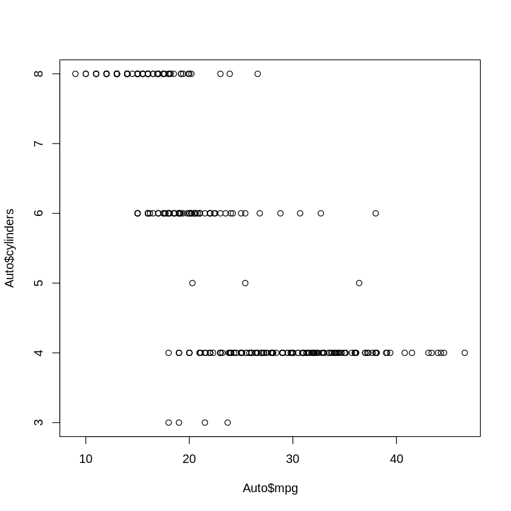

```r
plot(Auto$mpg, Auto$cylinders)
```

*More cylinders, less mpg.*

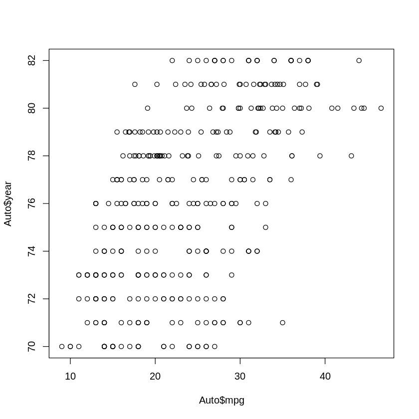

```r
plot(Auto$mpg, Auto$year)
```

*Cars become more efficient over time.*

- (f) Suppose that we wish to predict gas mileage (*mpg*) on the basis of the other variables. Do your plots suggest that any of the other variables might be useful in predicting *mpg*? Justify your answer.

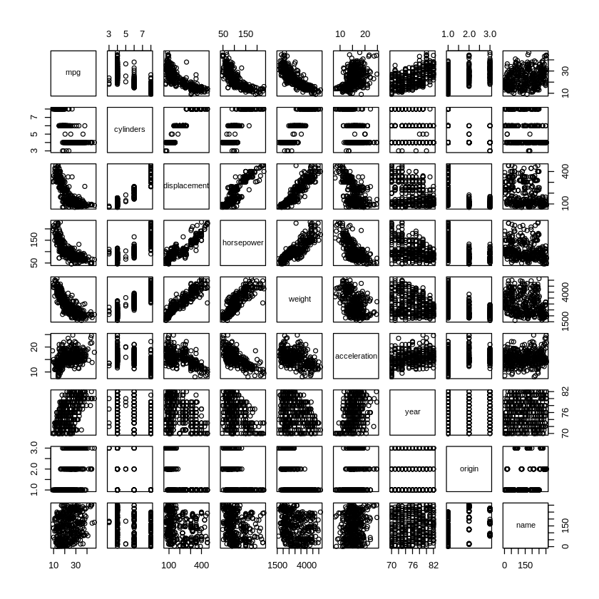

```r
pairs(Auto)
```

See descriptions of plots in (e)  
All of the predictors show some correlation with mpg. The name predictor has too little observations per name though, so using this as a predictor is likely to result in overfitting the data and will not generalize well.

*The cylinders, horsepower, year and origin can be used as predictors. Displacement and weight were not used because they are highly correlated with horespower and with each other.*

```r
cor(Auto$weight, Auto$horsepower)
```

0.864537737574144

```r
cor(Auto$weight, Auto$displacement)
```

0.932994404089011

```r
cor(Auto$displacement, Auto$horsepower)
```

0.897257001843469

**10.** This exercise involves the *Boston* housing data set.

- (a) To begin, load in the *Boston* data set. The *Boston* data set is part of the *MASS* library in *R*.

```r
library(MASS)
```

Now the data set is contained in the object *Boston*.

```r
Boston
```

| crim | zn | indus | chas | nox | rm | age | dis | rad | tax | ptratio | black | lstat | medv |
| --- | --- | --- | --- | --- | --- | --- | --- | --- | --- | --- | --- | --- | --- |
| 0.00632 | 18.0 | 2.31 | 0 | 0.538 | 6.575 | 65.2 | 4.0900 | 1 | 296 | 15.3 | 396.90 | 4.98 | 24.0 |
| 0.02731 | 0.0 | 7.07 | 0 | 0.469 | 6.421 | 78.9 | 4.9671 | 2 | 242 | 17.8 | 396.90 | 9.14 | 21.6 |
| 0.02729 | 0.0 | 7.07 | 0 | 0.469 | 7.185 | 61.1 | 4.9671 | 2 | 242 | 17.8 | 392.83 | 4.03 | 34.7 |
| 0.03237 | 0.0 | 2.18 | 0 | 0.458 | 6.998 | 45.8 | 6.0622 | 3 | 222 | 18.7 | 394.63 | 2.94 | 33.4 |
| 0.06905 | 0.0 | 2.18 | 0 | 0.458 | 7.147 | 54.2 | 6.0622 | 3 | 222 | 18.7 | 396.90 | 5.33 | 36.2 |
| 0.02985 | 0.0 | 2.18 | 0 | 0.458 | 6.430 | 58.7 | 6.0622 | 3 | 222 | 18.7 | 394.12 | 5.21 | 28.7 |
| 0.08829 | 12.5 | 7.87 | 0 | 0.524 | 6.012 | 66.6 | 5.5605 | 5 | 311 | 15.2 | 395.60 | 12.43 | 22.9 |
| 0.14455 | 12.5 | 7.87 | 0 | 0.524 | 6.172 | 96.1 | 5.9505 | 5 | 311 | 15.2 | 396.90 | 19.15 | 27.1 |
| 0.21124 | 12.5 | 7.87 | 0 | 0.524 | 5.631 | 100.0 | 6.0821 | 5 | 311 | 15.2 | 386.63 | 29.93 | 16.5 |
| 0.17004 | 12.5 | 7.87 | 0 | 0.524 | 6.004 | 85.9 | 6.5921 | 5 | 311 | 15.2 | 386.71 | 17.10 | 18.9 |
| 0.22489 | 12.5 | 7.87 | 0 | 0.524 | 6.377 | 94.3 | 6.3467 | 5 | 311 | 15.2 | 392.52 | 20.45 | 15.0 |
| 0.11747 | 12.5 | 7.87 | 0 | 0.524 | 6.009 | 82.9 | 6.2267 | 5 | 311 | 15.2 | 396.90 | 13.27 | 18.9 |
| 0.09378 | 12.5 | 7.87 | 0 | 0.524 | 5.889 | 39.0 | 5.4509 | 5 | 311 | 15.2 | 390.50 | 15.71 | 21.7 |
| 0.62976 | 0.0 | 8.14 | 0 | 0.538 | 5.949 | 61.8 | 4.7075 | 4 | 307 | 21.0 | 396.90 | 8.26 | 20.4 |
| 0.63796 | 0.0 | 8.14 | 0 | 0.538 | 6.096 | 84.5 | 4.4619 | 4 | 307 | 21.0 | 380.02 | 10.26 | 18.2 |
| 0.62739 | 0.0 | 8.14 | 0 | 0.538 | 5.834 | 56.5 | 4.4986 | 4 | 307 | 21.0 | 395.62 | 8.47 | 19.9 |
| 1.05393 | 0.0 | 8.14 | 0 | 0.538 | 5.935 | 29.3 | 4.4986 | 4 | 307 | 21.0 | 386.85 | 6.58 | 23.1 |
| 0.78420 | 0.0 | 8.14 | 0 | 0.538 | 5.990 | 81.7 | 4.2579 | 4 | 307 | 21.0 | 386.75 | 14.67 | 17.5 |
| 0.80271 | 0.0 | 8.14 | 0 | 0.538 | 5.456 | 36.6 | 3.7965 | 4 | 307 | 21.0 | 288.99 | 11.69 | 20.2 |
| 0.72580 | 0.0 | 8.14 | 0 | 0.538 | 5.727 | 69.5 | 3.7965 | 4 | 307 | 21.0 | 390.95 | 11.28 | 18.2 |
| 1.25179 | 0.0 | 8.14 | 0 | 0.538 | 5.570 | 98.1 | 3.7979 | 4 | 307 | 21.0 | 376.57 | 21.02 | 13.6 |
| 0.85204 | 0.0 | 8.14 | 0 | 0.538 | 5.965 | 89.2 | 4.0123 | 4 | 307 | 21.0 | 392.53 | 13.83 | 19.6 |
| 1.23247 | 0.0 | 8.14 | 0 | 0.538 | 6.142 | 91.7 | 3.9769 | 4 | 307 | 21.0 | 396.90 | 18.72 | 15.2 |
| 0.98843 | 0.0 | 8.14 | 0 | 0.538 | 5.813 | 100.0 | 4.0952 | 4 | 307 | 21.0 | 394.54 | 19.88 | 14.5 |
| 0.75026 | 0.0 | 8.14 | 0 | 0.538 | 5.924 | 94.1 | 4.3996 | 4 | 307 | 21.0 | 394.33 | 16.30 | 15.6 |
| 0.84054 | 0.0 | 8.14 | 0 | 0.538 | 5.599 | 85.7 | 4.4546 | 4 | 307 | 21.0 | 303.42 | 16.51 | 13.9 |
| 0.67191 | 0.0 | 8.14 | 0 | 0.538 | 5.813 | 90.3 | 4.6820 | 4 | 307 | 21.0 | 376.88 | 14.81 | 16.6 |
| 0.95577 | 0.0 | 8.14 | 0 | 0.538 | 6.047 | 88.8 | 4.4534 | 4 | 307 | 21.0 | 306.38 | 17.28 | 14.8 |
| 0.77299 | 0.0 | 8.14 | 0 | 0.538 | 6.495 | 94.4 | 4.4547 | 4 | 307 | 21.0 | 387.94 | 12.80 | 18.4 |
| 1.00245 | 0.0 | 8.14 | 0 | 0.538 | 6.674 | 87.3 | 4.2390 | 4 | 307 | 21.0 | 380.23 | 11.98 | 21.0 |
| ⋮ | ⋮ | ⋮ | ⋮ | ⋮ | ⋮ | ⋮ | ⋮ | ⋮ | ⋮ | ⋮ | ⋮ | ⋮ | ⋮ |
| 4.87141 | 0 | 18.10 | 0 | 0.614 | 6.484 | 93.6 | 2.3053 | 24 | 666 | 20.2 | 396.21 | 18.68 | 16.7 |
| 15.02340 | 0 | 18.10 | 0 | 0.614 | 5.304 | 97.3 | 2.1007 | 24 | 666 | 20.2 | 349.48 | 24.91 | 12.0 |
| 10.23300 | 0 | 18.10 | 0 | 0.614 | 6.185 | 96.7 | 2.1705 | 24 | 666 | 20.2 | 379.70 | 18.03 | 14.6 |
| 14.33370 | 0 | 18.10 | 0 | 0.614 | 6.229 | 88.0 | 1.9512 | 24 | 666 | 20.2 | 383.32 | 13.11 | 21.4 |
| 5.82401 | 0 | 18.10 | 0 | 0.532 | 6.242 | 64.7 | 3.4242 | 24 | 666 | 20.2 | 396.90 | 10.74 | 23.0 |
| 5.70818 | 0 | 18.10 | 0 | 0.532 | 6.750 | 74.9 | 3.3317 | 24 | 666 | 20.2 | 393.07 | 7.74 | 23.7 |
| 5.73116 | 0 | 18.10 | 0 | 0.532 | 7.061 | 77.0 | 3.4106 | 24 | 666 | 20.2 | 395.28 | 7.01 | 25.0 |
| 2.81838 | 0 | 18.10 | 0 | 0.532 | 5.762 | 40.3 | 4.0983 | 24 | 666 | 20.2 | 392.92 | 10.42 | 21.8 |
| 2.37857 | 0 | 18.10 | 0 | 0.583 | 5.871 | 41.9 | 3.7240 | 24 | 666 | 20.2 | 370.73 | 13.34 | 20.6 |
| 3.67367 | 0 | 18.10 | 0 | 0.583 | 6.312 | 51.9 | 3.9917 | 24 | 666 | 20.2 | 388.62 | 10.58 | 21.2 |
| 5.69175 | 0 | 18.10 | 0 | 0.583 | 6.114 | 79.8 | 3.5459 | 24 | 666 | 20.2 | 392.68 | 14.98 | 19.1 |
| 4.83567 | 0 | 18.10 | 0 | 0.583 | 5.905 | 53.2 | 3.1523 | 24 | 666 | 20.2 | 388.22 | 11.45 | 20.6 |
| 0.15086 | 0 | 27.74 | 0 | 0.609 | 5.454 | 92.7 | 1.8209 | 4 | 711 | 20.1 | 395.09 | 18.06 | 15.2 |
| 0.18337 | 0 | 27.74 | 0 | 0.609 | 5.414 | 98.3 | 1.7554 | 4 | 711 | 20.1 | 344.05 | 23.97 | 7.0 |
| 0.20746 | 0 | 27.74 | 0 | 0.609 | 5.093 | 98.0 | 1.8226 | 4 | 711 | 20.1 | 318.43 | 29.68 | 8.1 |
| 0.10574 | 0 | 27.74 | 0 | 0.609 | 5.983 | 98.8 | 1.8681 | 4 | 711 | 20.1 | 390.11 | 18.07 | 13.6 |
| 0.11132 | 0 | 27.74 | 0 | 0.609 | 5.983 | 83.5 | 2.1099 | 4 | 711 | 20.1 | 396.90 | 13.35 | 20.1 |
| 0.17331 | 0 | 9.69 | 0 | 0.585 | 5.707 | 54.0 | 2.3817 | 6 | 391 | 19.2 | 396.90 | 12.01 | 21.8 |
| 0.27957 | 0 | 9.69 | 0 | 0.585 | 5.926 | 42.6 | 2.3817 | 6 | 391 | 19.2 | 396.90 | 13.59 | 24.5 |
| 0.17899 | 0 | 9.69 | 0 | 0.585 | 5.670 | 28.8 | 2.7986 | 6 | 391 | 19.2 | 393.29 | 17.60 | 23.1 |
| 0.28960 | 0 | 9.69 | 0 | 0.585 | 5.390 | 72.9 | 2.7986 | 6 | 391 | 19.2 | 396.90 | 21.14 | 19.7 |
| 0.26838 | 0 | 9.69 | 0 | 0.585 | 5.794 | 70.6 | 2.8927 | 6 | 391 | 19.2 | 396.90 | 14.10 | 18.3 |
| 0.23912 | 0 | 9.69 | 0 | 0.585 | 6.019 | 65.3 | 2.4091 | 6 | 391 | 19.2 | 396.90 | 12.92 | 21.2 |
| 0.17783 | 0 | 9.69 | 0 | 0.585 | 5.569 | 73.5 | 2.3999 | 6 | 391 | 19.2 | 395.77 | 15.10 | 17.5 |
| 0.22438 | 0 | 9.69 | 0 | 0.585 | 6.027 | 79.7 | 2.4982 | 6 | 391 | 19.2 | 396.90 | 14.33 | 16.8 |
| 0.06263 | 0 | 11.93 | 0 | 0.573 | 6.593 | 69.1 | 2.4786 | 1 | 273 | 21.0 | 391.99 | 9.67 | 22.4 |
| 0.04527 | 0 | 11.93 | 0 | 0.573 | 6.120 | 76.7 | 2.2875 | 1 | 273 | 21.0 | 396.90 | 9.08 | 20.6 |
| 0.06076 | 0 | 11.93 | 0 | 0.573 | 6.976 | 91.0 | 2.1675 | 1 | 273 | 21.0 | 396.90 | 5.64 | 23.9 |
| 0.10959 | 0 | 11.93 | 0 | 0.573 | 6.794 | 89.3 | 2.3889 | 1 | 273 | 21.0 | 393.45 | 6.48 | 22.0 |
| 0.04741 | 0 | 11.93 | 0 | 0.573 | 6.030 | 80.8 | 2.5050 | 1 | 273 | 21.0 | 396.90 | 7.88 | 11.9 |

Read about the data set:

```r
?Boston
```

How many rows are in this data set? How many columns? What do the rows and columns represent?

```r
dim(Boston)
```

1. 506

2. 14

506 rows, 14 columns  
14 features, 506 housing values in Boston suburbs

- (b) Make some pairwise scatterplots of the predictors (columns) in this data set. Describe your ﬁndings.

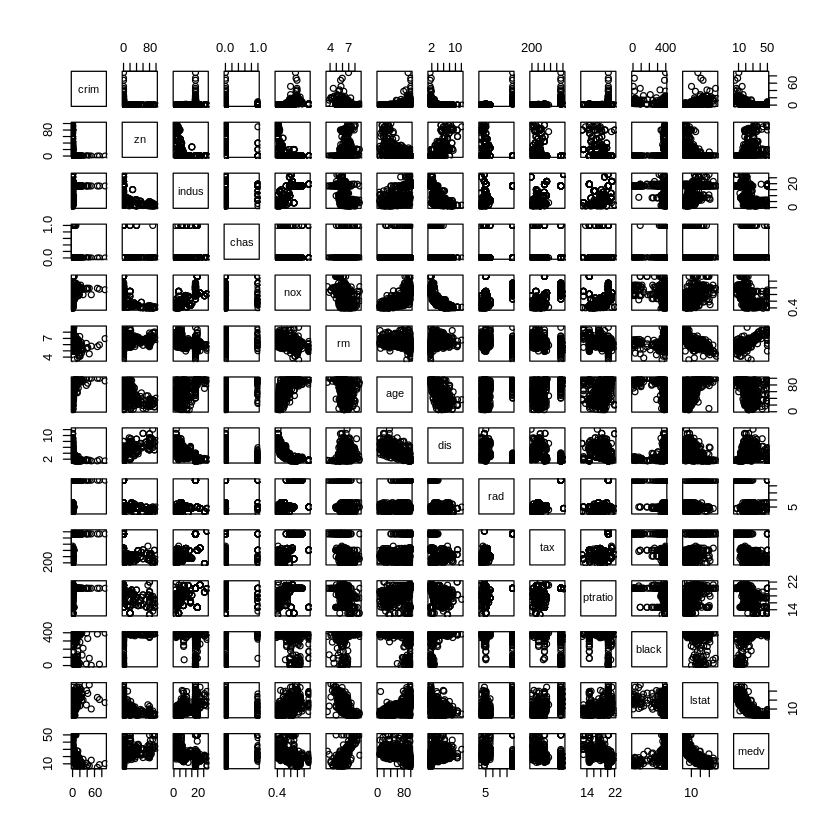

```r
pairs(Boston)
```

*crim* correlates with: *age, dis, rad, tax, ptratio*  
*zn* correlates with: *indus, nox, age, lstat*  
*indus* correlates with: *age, dis*  
*nox* correlates with: *age, dis*  
*dis* correlates with: *lstat*  
*lstat* correlates with: *medv*

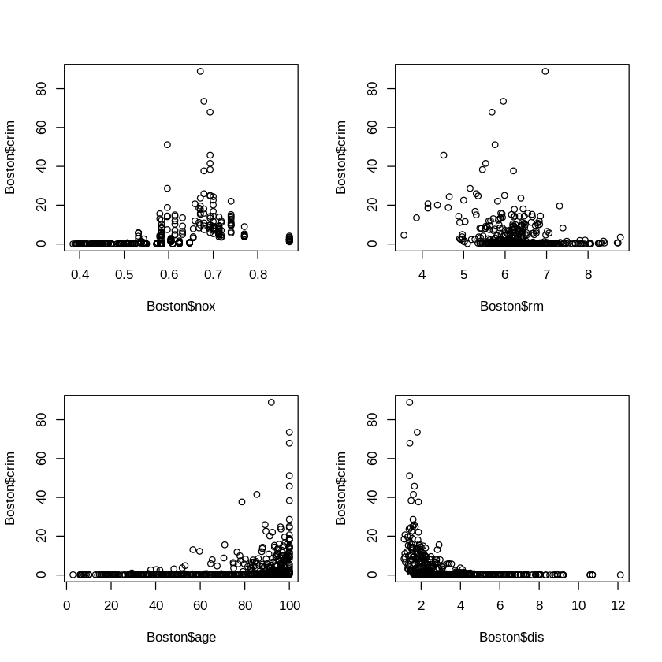

```r
par(mfrow = c(2, 2))
plot(Boston$nox, Boston$crim)
plot(Boston$rm, Boston$crim)
plot(Boston$age, Boston$crim)
plot(Boston$dis, Boston$crim)
```

- (c) Are any of the predictors associated with per capita crime rate? If so, explain the relationship.

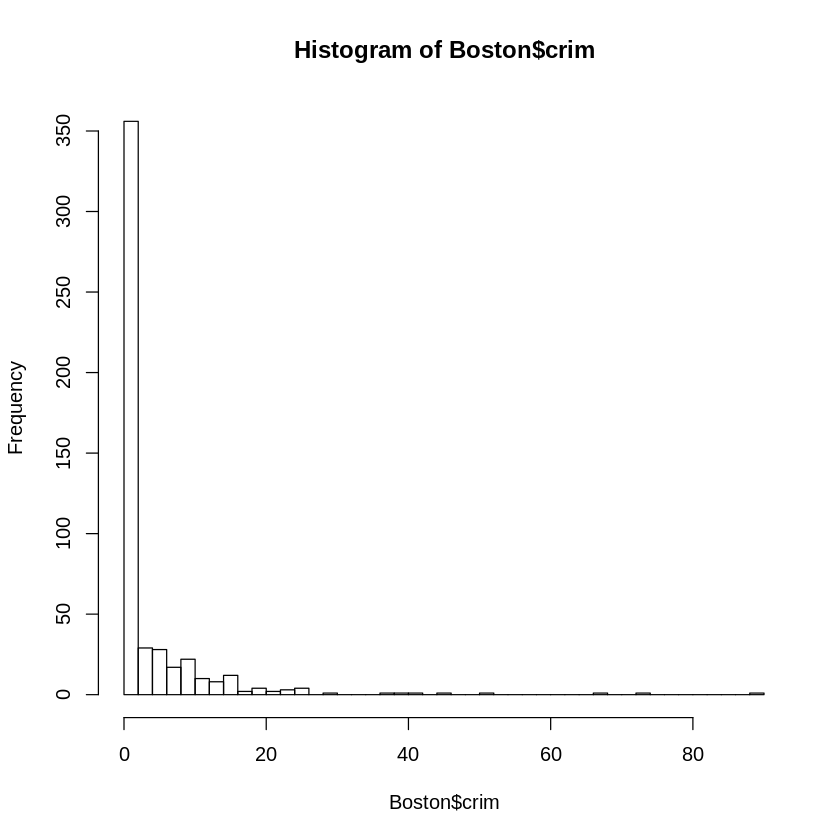

```r
hist(Boston$crim, breaks = 50)
```

*Most suburbs do not have any crime ($80\%$ of data falls in crim < 20).*

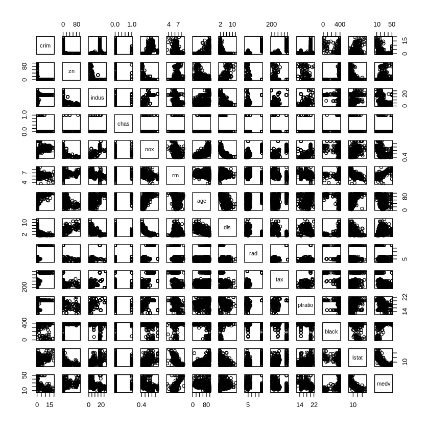

```r
pairs(Boston[Boston$crim < 20, ])
```

*There may be a relationship between crim and age, dis, rad, tax and ptratio.*

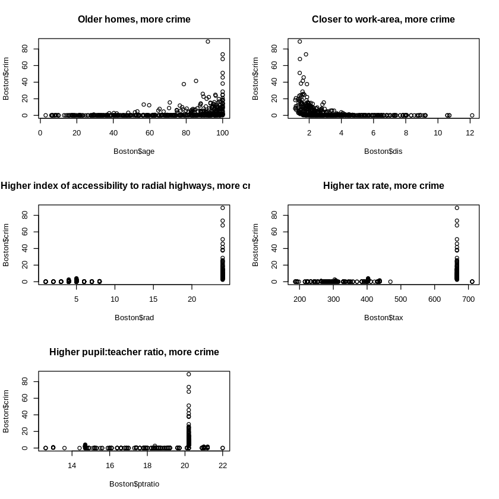

```r
par(mfrow = c(3, 2))
plot(Boston$age, Boston$crim, main = "Older homes, more crime")
plot(Boston$dis, Boston$crim, main = "Closer to work-area, more crime")
plot(Boston$rad, Boston$crim, main = "Higher index of accessibility to radial highways, more crime")
plot(Boston$tax, Boston$crim, main = "Higher tax rate, more crime")
plot(Boston$ptratio, Boston$crim, main = "Higher pupil:teacher ratio, more crime")
```

- (d) Do any of the suburbs of Boston appear to have particularly high crime rates? Tax rates? Pupil-teacher ratios? Comment on the range of each predictor.

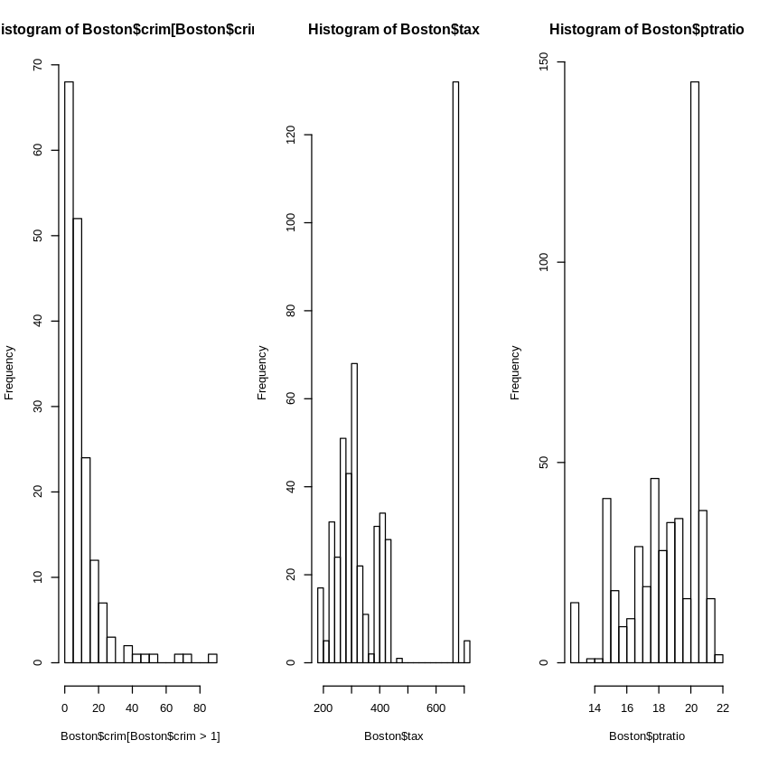

```r
par(mfrow=c(1,3))
hist(Boston$crim[Boston$crim > 1], breaks=25)
hist(Boston$tax, breaks=25)
hist(Boston$ptratio, breaks=25)
```

*Most cities have low crime rates, but there is a long tail: 18 suburbs appear to have a crime rate > 20, reaching to above 80.*

*There is a large divide between suburbs with low tax rates and a peak at 660-680.*

*A skew towards high ratios, but no particularly high ratios.*

- (e) How many of the suburbs in this data set bound the Charles river?

```r
nrow(Boston[Boston$chas == 1, ])
```

35

- (f) What is the median pupil-teacher ratio among the towns in this data set?

```r
median(Boston$ptratio)
```

19.05

- (g) Which suburb of Boston has lowest median value of owneroccupied homes? What are the values of the other predictors or that suburb, and how do those values compare to the overall ranges for those predictors? Comment on your ﬁndings.

```r
t(subset(Boston, medv == min(Boston$medv)))
```

|  | 399 | 406 |
| --- | --- | --- |
| crim | 38.3518 | 67.9208 |
| zn | 0.0000 | 0.0000 |
| indus | 18.1000 | 18.1000 |
| chas | 0.0000 | 0.0000 |
| nox | 0.6930 | 0.6930 |
| rm | 5.4530 | 5.6830 |
| age | 100.0000 | 100.0000 |
| dis | 1.4896 | 1.4254 |
| rad | 24.0000 | 24.0000 |
| tax | 666.0000 | 666.0000 |
| ptratio | 20.2000 | 20.2000 |
| black | 396.9000 | 384.9700 |
| lstat | 30.5900 | 22.9800 |
| medv | 5.0000 | 5.0000 |

```r
summary(Boston)
```

```
      crim                zn             indus            chas
 Min.   : 0.00632   Min.   :  0.00   Min.   : 0.46   Min.   :0.00000
 1st Qu.: 0.08204   1st Qu.:  0.00   1st Qu.: 5.19   1st Qu.:0.00000
 Median : 0.25651   Median :  0.00   Median : 9.69   Median :0.00000
 Mean   : 3.61352   Mean   : 11.36   Mean   :11.14   Mean   :0.06917
 3rd Qu.: 3.67708   3rd Qu.: 12.50   3rd Qu.:18.10   3rd Qu.:0.00000
 Max.   :88.97620   Max.   :100.00   Max.   :27.74   Max.   :1.00000
      nox               rm             age              dis
 Min.   :0.3850   Min.   :3.561   Min.   :  2.90   Min.   : 1.130
 1st Qu.:0.4490   1st Qu.:5.886   1st Qu.: 45.02   1st Qu.: 2.100
 Median :0.5380   Median :6.208   Median : 77.50   Median : 3.207
 Mean   :0.5547   Mean   :6.285   Mean   : 68.57   Mean   : 3.795
 3rd Qu.:0.6240   3rd Qu.:6.623   3rd Qu.: 94.08   3rd Qu.: 5.188
 Max.   :0.8710   Max.   :8.780   Max.   :100.00   Max.   :12.127
      rad              tax           ptratio          black
 Min.   : 1.000   Min.   :187.0   Min.   :12.60   Min.   :  0.32
 1st Qu.: 4.000   1st Qu.:279.0   1st Qu.:17.40   1st Qu.:375.38
 Median : 5.000   Median :330.0   Median :19.05   Median :391.44
 Mean   : 9.549   Mean   :408.2   Mean   :18.46   Mean   :356.67
 3rd Qu.:24.000   3rd Qu.:666.0   3rd Qu.:20.20   3rd Qu.:396.23
 Max.   :24.000   Max.   :711.0   Max.   :22.00   Max.   :396.90
     lstat            medv
 Min.   : 1.73   Min.   : 5.00
 1st Qu.: 6.95   1st Qu.:17.02
 Median :11.36   Median :21.20
 Mean   :12.65   Mean   :22.53
 3rd Qu.:16.95   3rd Qu.:25.00
 Max.   :37.97   Max.   :50.00
```

*Not the best place to live, but certainly not the worst.*

- (h) In this data set, how many of the suburbs average more than seven rooms per dwelling? More than eight rooms per dwelling? Comment on the suburbs that average more than eight rooms per dwelling.

```r
nrow(Boston[Boston$rm > 7, ])
```

64

```r
nrow(Boston[Boston$rm > 8, ])
```

13

```r
summary(subset(Boston, rm > 8))
```

```
      crim               zn            indus             chas
 Min.   :0.02009   Min.   : 0.00   Min.   : 2.680   Min.   :0.0000
 1st Qu.:0.33147   1st Qu.: 0.00   1st Qu.: 3.970   1st Qu.:0.0000
 Median :0.52014   Median : 0.00   Median : 6.200   Median :0.0000
 Mean   :0.71879   Mean   :13.62   Mean   : 7.078   Mean   :0.1538
 3rd Qu.:0.57834   3rd Qu.:20.00   3rd Qu.: 6.200   3rd Qu.:0.0000
 Max.   :3.47428   Max.   :95.00   Max.   :19.580   Max.   :1.0000
      nox               rm             age             dis
 Min.   :0.4161   Min.   :8.034   Min.   : 8.40   Min.   :1.801
 1st Qu.:0.5040   1st Qu.:8.247   1st Qu.:70.40   1st Qu.:2.288
 Median :0.5070   Median :8.297   Median :78.30   Median :2.894
 Mean   :0.5392   Mean   :8.349   Mean   :71.54   Mean   :3.430
 3rd Qu.:0.6050   3rd Qu.:8.398   3rd Qu.:86.50   3rd Qu.:3.652
 Max.   :0.7180   Max.   :8.780   Max.   :93.90   Max.   :8.907
      rad              tax           ptratio          black
 Min.   : 2.000   Min.   :224.0   Min.   :13.00   Min.   :354.6
 1st Qu.: 5.000   1st Qu.:264.0   1st Qu.:14.70   1st Qu.:384.5
 Median : 7.000   Median :307.0   Median :17.40   Median :386.9
 Mean   : 7.462   Mean   :325.1   Mean   :16.36   Mean   :385.2
 3rd Qu.: 8.000   3rd Qu.:307.0   3rd Qu.:17.40   3rd Qu.:389.7
 Max.   :24.000   Max.   :666.0   Max.   :20.20   Max.   :396.9
     lstat           medv
 Min.   :2.47   Min.   :21.9
 1st Qu.:3.32   1st Qu.:41.7
 Median :4.14   Median :48.3
 Mean   :4.31   Mean   :44.2
 3rd Qu.:5.12   3rd Qu.:50.0
 Max.   :7.44   Max.   :50.0
```

```r
summary(subset(Boston, rm > 8))
```

```
      crim               zn            indus             chas
 Min.   :0.02009   Min.   : 0.00   Min.   : 2.680   Min.   :0.0000
 1st Qu.:0.33147   1st Qu.: 0.00   1st Qu.: 3.970   1st Qu.:0.0000
 Median :0.52014   Median : 0.00   Median : 6.200   Median :0.0000
 Mean   :0.71879   Mean   :13.62   Mean   : 7.078   Mean   :0.1538
 3rd Qu.:0.57834   3rd Qu.:20.00   3rd Qu.: 6.200   3rd Qu.:0.0000
 Max.   :3.47428   Max.   :95.00   Max.   :19.580   Max.   :1.0000
      nox               rm             age             dis
 Min.   :0.4161   Min.   :8.034   Min.   : 8.40   Min.   :1.801
 1st Qu.:0.5040   1st Qu.:8.247   1st Qu.:70.40   1st Qu.:2.288
 Median :0.5070   Median :8.297   Median :78.30   Median :2.894
 Mean   :0.5392   Mean   :8.349   Mean   :71.54   Mean   :3.430
 3rd Qu.:0.6050   3rd Qu.:8.398   3rd Qu.:86.50   3rd Qu.:3.652
 Max.   :0.7180   Max.   :8.780   Max.   :93.90   Max.   :8.907
      rad              tax           ptratio          black
 Min.   : 2.000   Min.   :224.0   Min.   :13.00   Min.   :354.6
 1st Qu.: 5.000   1st Qu.:264.0   1st Qu.:14.70   1st Qu.:384.5
 Median : 7.000   Median :307.0   Median :17.40   Median :386.9
 Mean   : 7.462   Mean   :325.1   Mean   :16.36   Mean   :385.2
 3rd Qu.: 8.000   3rd Qu.:307.0   3rd Qu.:17.40   3rd Qu.:389.7
 Max.   :24.000   Max.   :666.0   Max.   :20.20   Max.   :396.9
     lstat           medv
 Min.   :2.47   Min.   :21.9
 1st Qu.:3.32   1st Qu.:41.7
 Median :4.14   Median :48.3
 Mean   :4.31   Mean   :44.2
 3rd Qu.:5.12   3rd Qu.:50.0
 Max.   :7.44   Max.   :50.0
```

*Relatively lower crime (comparing range), lower lstat (comparing range).*